# 第10回 並べ替え検定とブートストラップで、差を確かめる

見出しを替えると、クリックは増えるのか

# 導入

## 第9回はペンギン、今日は見出し

① 今日のデータ●○○

- 第9回は、ペンギンの体の測り方を、楕円の群に分けた
- 今日は、ニュースの見出しを比べた実験のデータ
- 見出しを替えると、読む人は増えるのか

## A/Bテスト

① 今日のデータ●●○

- 来た人を、でたらめに2つの組に分ける
- 組ごとに違う見出しを見せ、クリックした人の割合を比べる
- ウェブの会社は、毎日のように、この実験をしている

## 公開された実験のデータ

① 今日のデータ●●●

- ニュースサイトUpworthyが、2013〜2015年の見出しのA/Bテストを公開した
- 研究者がまとめ、論文と一緒に公開（Upworthy Research Archive、CC BY 4.0）
- ふつうは社外に出ない実験の記録が、何千件も読める

## 見出しを何案も作る

② 場面●○○

- 編集者は、1つの記事に見出しを何案も作る
- どの案を使うかを、A/Bテストで決めていた
- 今日は、そのテストの結果を読み直す

## 決めたいこと

② 場面●●○

- 2つの見出しのクリック率に差がある。その差は本物か
- 本物なら、どれくらいの差か
- 偶然でも出る差なら、見出しを替える意味は無い

## 難しさ：差はいつも出る

② 場面●●●

- クリックする人は、100人に1〜2人
- 同じ見出しを2つの組に見せても、クリック率はぴったり同じにはならない
- 出てきた差が、偶然の揺れより大きいかを見分けたい

## 手元のデータ

③ 手元のデータ●○

- 4,873件のテストの、22,666の案（見出しなど）。1行が「1つのテストの中の1つの案」
- 列：テストの番号、見出し、表示（見せた回数）、クリック（クリックされた回数）
- 1つのテストの案は、来た人に、でたらめに割り当てられている

## データをのぞく

③ 手元のデータ●●

|  | 見出し | 表示 | クリック |
| --- | --- | --- | --- |
| 0 | They're Being Called 'Walmart's Worst Nightmare.… | 3052 | 150 |
| 1 | They're Being Called 'Walmart's Worst Nightmare.… | 3033 | 122 |
| 2 | They're Being Called 'Walmart's Worst Nightmare.… | 3092 | 110 |

- 先頭の3行は、同じテストの中の3つの案（ウォルマートの記事）

## 最後に出す答え

④ 今日の問い●○

- 見出しを替えたときのクリック率の差は、偶然でも出る差か
- 本物なら、差はどれくらいか

## 今日の問い

④ 今日の問い●●

見出しを替えると、本当にクリックは増えるのか？ その差は、偶然でも出る差ではないか？

## もう1つのねらい：乱数でくり返す

⑤ もう1つのねらい●

- 乱数で取り直す1回分を`for`でくり返し、結果をリストにためて、分布を作れるようになる
- 第4回の「リストにためる」のおさらい
- お手本ごとに、コードを1行ずつ読み、変数の中身を見る

# 今日の一周

## 結果だけで一度通す

⑥ 今日の一周●○○○○○○

- まず、今日の解析を、結果だけで一度通して見る
- コードはあとで。どんな結論になるかを先に知っておく

## 一周①：2つの見出し

⑥ 今日の一周●●○○○○○

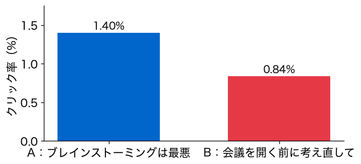

- 同じ記事の2つの見出し。Aのクリック率は、Bの1.67倍

## 一周②：札を1万回混ぜる

⑥ 今日の一周●●●○○○○

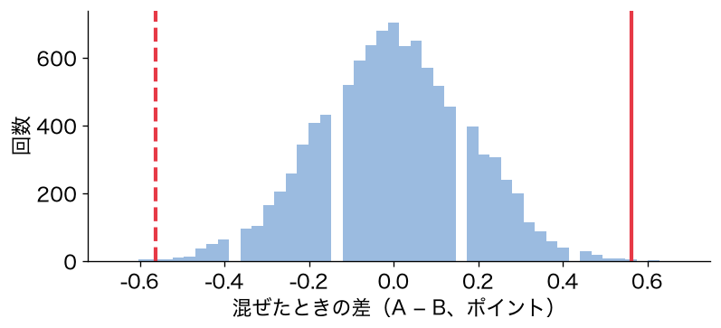

- 見出しの札を混ぜて差を測る。赤い線（実際の差）より外は、1万回で22回だけ

## 一周③：式の検定でも同じ

⑥ 今日の一周●●●●○○○

- 並べ替え（1万回）のp値は0.0022
- カイ二乗検定という式で出すと0.0019。ほとんど同じ
- 偶然では出にくい差、と言える

## 一周④：差はどれくらい？

⑥ 今日の一周●●●●●○○

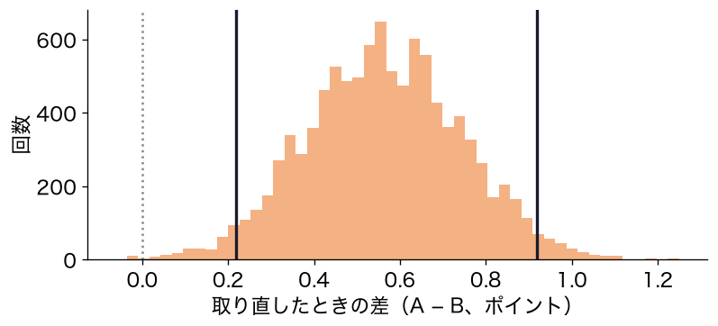

- 手元のデータから取り直すと、差は0.22〜0.92ポイント（95%区間）

## 一周⑤：同じ見出しで2倍

⑥ 今日の一周●●●●●●○

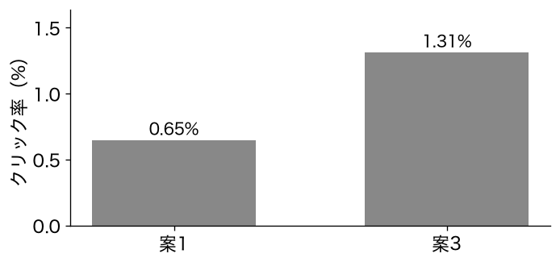

- えっ、まったく同じ見出しの2案で、クリック率が2倍違う。p=0.004で「有意」

## 一周は5つの段

⑥ 今日の一周●●●●●●●

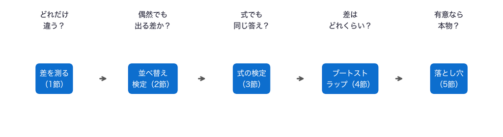

- このあと、5つの段の中身を、1つずつ開けていく

## 問いとやること①②

⑦ 問いとやること●○

- 差を測る：どれだけ違う？ → クリック率の差と比を出し、表示1回を1つの0/1にする（1節）
- 並べ替え検定：偶然でも出る差か？ → 見出しの札を1万回混ぜて、差の分布を作り、p値を数える（2節）

## 問いとやること③④⑤

⑦ 問いとやること●●

- 式の検定：式でも同じ答え？ → カイ二乗検定とt検定のp値を、並べ替えと比べる（3節）
- ブートストラップ：差はどれくらい？ → 戻しながら取り直して、差の区間を作る（4節）
- 落とし穴：有意なら本物？ → 同じ見出しどうしのテストを、何度も比べる（5節）

## 今日の進め方

⑧ 今日の進め方●

- 段ごとに、スライドで聞く → ノートで実行して答える
- 段の終わりの「ノートへ」で、予想を書き、1か所を替えて実行し、予想と比べる
- 予想は外れてかまわない

# 0. 準備

## まずは道具を呼び出す

- 0節は、道具を呼び出すだけ。ノートで1節と続けて実行する
- 今日は、検定の道具`scipy.stats`も使う（`from scipy import stats`）

# 1. どれだけ違う？

## 段1：差を測る

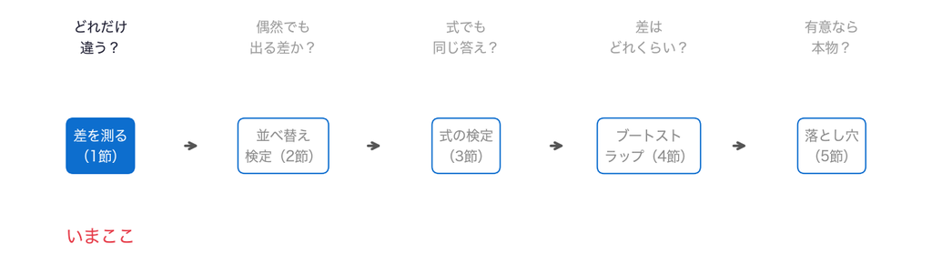

- 問い：2つの見出しで、クリック率はどれだけ違うか

## お手本：テストの一覧を読む

1節 ① 読む●○

```python
# データはこのリポジトリから読み込む
DATA_DIR = ('https://raw.githubusercontent.com/k0heiun0/'
            'applied_exercise_preview/main/shared/data')
df = pd.read_csv(f'{DATA_DIR}/upworthy_exploratory.csv.gz')
df = df.rename(columns={'clickability_test_id': 'テスト',
                        'headline': '見出し',
                        'impressions': '表示', 'clicks': 'クリック'})
print(len(df), df['テスト'].nunique())
```

```
22666 4873
```

## 1行ずつ：テストの一覧を読む

1節 ① 読む●●

```python
# データはこのリポジトリから読み込む
DATA_DIR = ('https://raw.githubusercontent.com/k0heiun0/'
            'applied_exercise_preview/main/shared/data')
df = pd.read_csv(f'{DATA_DIR}/upworthy_exploratory.csv.gz')
df = df.rename(columns={'clickability_test_id': 'テスト',
                        'headline': '見出し',
                        'impressions': '表示', 'clicks': 'クリック'})
print(len(df), df['テスト'].nunique())
```

- `DATA_DIR`の行と`read_csv`の行：データの置き場所と、縮めた表（`.gz`）を読む
- `rename`の3行：使う4本の列に、日本語の名前を付ける（第5回の辞書）
- `print`の行：行の数（案の数）と、テストの番号の種類の数（`nunique`）

## お手本：1つのテストを取り出す

1節 ② 取り出す●○○

```python
t = df[df['テスト'] == '52d0ad1b1229172bb2000a47']
t[['見出し', '表示', 'クリック']]
```

|  | 見出し | 表示 | クリック |
| --- | --- | --- | --- |
| 2964 | Why Brainstorming Is A No-Good, Very Bad Thing... | 6642 | 93 |
| 2965 | Next Time You Try To Assemble A Meeting At Wor... | 6810 | 57 |

## 1行ずつ：1つのテストを取り出す

1節 ② 取り出す●●○

```python
t = df[df['テスト'] == '52d0ad1b1229172bb2000a47']
t[['見出し', '表示', 'クリック']]
```

- 1行目：テストの番号が一致する行だけを取り出す（第1回の、条件で絞る）
- 2行目：見出しと表示とクリックの列を見る
- 画像と、見出しの下の短い説明は、2案とも同じ。違うのは見出しだけ

## 2つの見出し

1節 ② 取り出す●●●

- A：「ブレインストーミングは最悪。今すぐ、みんなでやめるべき理由」
- B：「次に、これのために職場で会議を開こうとしたら、考え直して」
- 2014年1月。どちらも、同じ記事（会議の進め方の話）への入り口

## クリック率

1節 ③ 率●○○

- 案$j$の表示の数を$n_j$、クリックの数を$k_j$とする
- クリック率は $\hat{p}_j = \dfrac{k_j}{n_j}$
- $\hat{p}$の帽子は「手元のデータから出した値」のしるし

## お手本：クリック率

1節 ③ 率●●○

```python
n = t['表示'].tolist()
k = t['クリック'].tolist()
pA = k[0] / n[0]
pB = k[1] / n[1]
print(n, k)
print(round(pA, 4), round(pB, 4))
```

```
[6642, 6810] [93, 57]
0.014 0.0084
```

## 1行ずつ：クリック率

1節 ③ 率●●●

```python
n = t['表示'].tolist()
k = t['クリック'].tolist()
pA = k[0] / n[0]
pB = k[1] / n[1]
print(n, k)
print(round(pA, 4), round(pB, 4))
```

- 1・2行目：表示とクリックの列を、リストにする（第4回のリスト）
- 3・4行目：`[0]`がA、`[1]`がB。クリックを表示で割る
- 5・6行目：Aは1.40%、Bは0.84%

## 物差しは2つ：差と比

1節 ④ 差と比●○○

- 差：$\hat{p}_A - \hat{p}_B$。何ポイント違うか（1ポイント＝1%の差）
- 比：$\hat{p}_A / \hat{p}_B$。何倍か
- 率が小さいときは、差は小さく見え、比は大きく見える。両方を見る

## お手本：差と比

1節 ④ 差と比●●○

```python
print(round(pA - pB, 4))
print(round(pA / pB, 2))
```

```
0.0056
1.67
```

- 差は0.0056（0.56ポイント）、比は1.67倍

## 1万回なら、何クリック？

1節 ④ 差と比●●●

- 0.56ポイントは、1万回の表示で56クリックの差
- 小さく見えるが、比で言えば1.67倍
- 何百万回も表示する見出しなら、大きな違いになる

## 表示1回を1つの0/1に

1節 ⑤ 0/1●○○○○○

- 表示1回ごとに、クリックされたら1、されなかったら0と書く
- Aは、1が93個、0が6,549個の並び
- こうしておくと、あとで「混ぜる」「取り直す」ができる

## 0/1の並び（小さな例）

1節 ⑤ 0/1●●○○○○

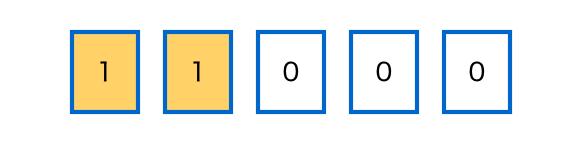

- 表示1回が1枚の札。クリックされた札（黄色）が1、それ以外が0

## お手本：0/1の列にする

1節 ⑤ 0/1●●●○○○

```python
a = np.repeat([1, 0], [k[0], n[0] - k[0]])
b = np.repeat([1, 0], [k[1], n[1] - k[1]])
print(len(a), a.sum(), round(a.mean(), 4))
print(len(b), b.sum(), round(b.mean(), 4))
```

```
6642 93 0.014
6810 57 0.0084
```

## 1行ずつ：0/1の列にする

1節 ⑤ 0/1●●●●○○

```python
a = np.repeat([1, 0], [k[0], n[0] - k[0]])
b = np.repeat([1, 0], [k[1], n[1] - k[1]])
print(len(a), a.sum(), round(a.mean(), 4))
print(len(b), b.sum(), round(b.mean(), 4))
```

- 1行目：1を`k[0]`個（93）、0を`n[0] - k[0]`個（6,549）並べる（`np.repeat`）
- 2行目：Bも同じ
- 3・4行目：長さ・1の数・平均

## 中身を見る：小さな数で

1節 ⑤ 0/1●●●●●○

```python
small = np.repeat([1, 0], [2, 3])
print(small)
print(small.sum(), small.mean())
```

```
[1 1 0 0 0]
2 0.4
```

- 1を2個、0を3個。和はクリックの数、平均はクリック率

## 平均がクリック率

1節 ⑤ 0/1●●●●●●

- 0/1の列$y_1, \dots, y_n$の平均は $\bar{y} = \dfrac{1}{n}\sum_{i=1}^{n} y_i = \dfrac{k}{n}$
- 1の個数を数えて、全体で割ったのと同じ
- 割合の比べ方は、平均の比べ方と同じに扱える

## この差は本物か？

1節 ⑥ 本物か●

- 同じ見出しを2つの組に見せても、クリック率は少しずれる
- 0.56ポイントの差は、そのずれより大きいのか
- まだ分からない。次の段で、偶然のずれを作って比べる

## 結果を見る前に、予想を書く

1節 ⑦ 予想●

- 同じ見出しを2つの組に見せたら、クリック率はどれくらいずれるだろうか
- 予想を書いてから、2節へ進む

## TODO①：テストを替える

1節 ⑧ テストを替える●

```python
# TODO: テストの番号を '51c3bde0b95fc097420034ec' に替えて実行する
tx = df[df['テスト'] == '52d0ad1b1229172bb2000a47']
print(tx['見出し'].tolist())
print((tx['クリック'] / tx['表示']).round(4).tolist())
```

- 別のテスト（10代の記事）の2つの見出し：①「この男の子たちを見ると、10代の男子の頭の中がまったく分からない」②「10代が、ひどい劣等感を笑えるパフォーマンスに変える」
- 予想：どちらの見出しが、よくクリックされるか

## ここまでで分かったこと

1節 ⑨ 分かったこと●

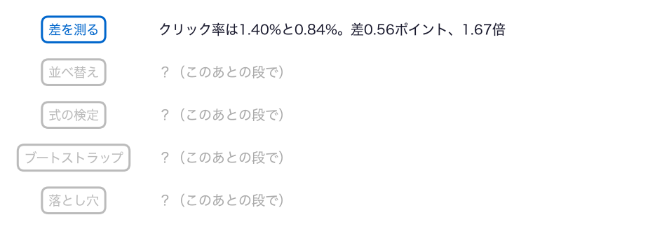

- まだ分からないのは、この差が、偶然でも出る差かどうか

## ノートへ：0・1節

1節 10 ノートへ●

- 0・1節のセルを上から実行し、スライドと同じ数が出るか確かめる
- 予想を書く：同じ見出しを2つの組に見せたら、どれくらいずれるか
- TODO①：予想を書く → テストの番号を替えて実行 → 予想と比べる

動画の人は、ここで一時停止。

## 答え合わせ：TODO①

1節 11 答え合わせ●

```
[0.0116, 0.0182]
```

- ①「男の子たち」は1.16%、②「劣等感を笑いに」は1.82%。②が1.57倍
- 予想は当たりましたか。見出しを読んで当てるのは、案外むずかしい

# 2. 偶然でも出る差か？

## 段2：並べ替え検定

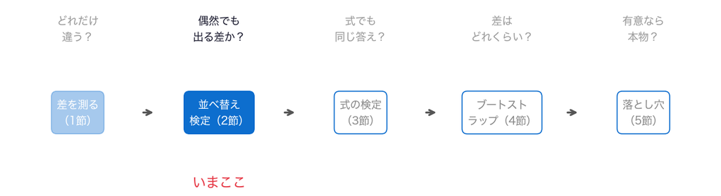

- 問い：0.56ポイントの差は、偶然でも出る差か

## 前の段から

2節 ① 前の段から●

- Aのクリック率は1.40%、Bは0.84%。差は0.56ポイント、比は1.67倍
- 表示1回を1つの0/1にした。平均がクリック率
- 同じ見出しでも、組が違えば率は少しずれる。そのずれの大きさを知りたい

## 差が無い世界

2節 ② 差が無い世界●○

- 仮に、見出しがクリックに関係ないとする
- それなら、クリックする人は、AでもBでもクリックした
- AとBの札は、ただの名札。付け替えても、クリックの並びは変わらない

## 帰無仮説

2節 ② 差が無い世界●●

- 「差が無い」とする仮の考えを、帰無仮説という
- 帰無仮説のもとで、札を付け替えた差をたくさん作る
- 実際の差が、その中でどれくらい珍しいかを見る

## 小さな例：8人

2節 ③ 小さな例●○

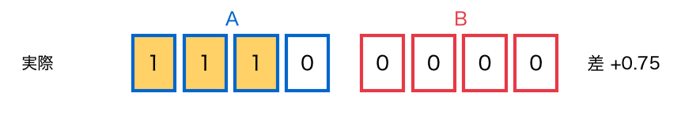

- Aを見た4人のうち3人、Bを見た4人のうち0人がクリック。差は0.75

## 札を混ぜる

2節 ③ 小さな例●●

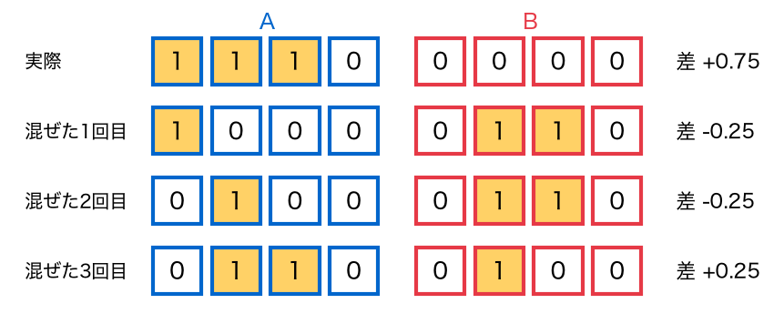

- 8枚の札を混ぜ、前の4枚をA、後ろの4枚をBとして、差を測る

## お手本：8人で混ぜる

2節 ④ 8人●○○○○○

```python
x8 = np.array([1, 1, 1, 0, 0, 0, 0, 0])
rng = np.random.default_rng(0)
d8 = []
for i in range(1000):
    y = rng.permutation(x8)
    d8.append(y[:4].mean() - y[4:].mean())
d8 = np.array(d8)
print((np.abs(d8) >= 0.75).mean())
```

```
0.147
```

## 1行ずつ：8人で混ぜる①

2節 ④ 8人●●○○○○

```python
x8 = np.array([1, 1, 1, 0, 0, 0, 0, 0])
rng = np.random.default_rng(0)
d8 = []
for i in range(1000):
    y = rng.permutation(x8)
    d8.append(y[:4].mean() - y[4:].mean())
d8 = np.array(d8)
print((np.abs(d8) >= 0.75).mean())
```

- 1行目：8人の0/1。前の4人がA、後ろの4人がB
- 2行目：乱数を出す道具`rng`を、シード0で作る（同じシードなら、同じ乱数が出る）
- 3行目：差をためる空のリスト（第4回）

## 1行ずつ：8人で混ぜる②

2節 ④ 8人●●●○○○

```python
x8 = np.array([1, 1, 1, 0, 0, 0, 0, 0])
rng = np.random.default_rng(0)
d8 = []
for i in range(1000):
    y = rng.permutation(x8)
    d8.append(y[:4].mean() - y[4:].mean())
d8 = np.array(d8)
print((np.abs(d8) >= 0.75).mean())
```

- 4・5行目：1,000回くり返す。毎回、8枚を混ぜた並び`y`を作る（`permutation`）
- 6行目：前の4枚の平均 − 後ろの4枚の平均を、リストの後ろに足す
- 7・8行目：配列にして、差の大きさ（`abs`）が0.75以上だった割合

## 中身を見る：3回だけ

2節 ④ 8人●●●●○○

```python
rng = np.random.default_rng(0)
d8_2 = []
for i in range(3):
    y = rng.permutation(x8)
    d8_2.append(y[:4].mean() - y[4:].mean())
    print(y, np.array(d8_2))
```

```
[1 0 0 0 0 1 1 0] [-0.25]
[0 1 0 0 0 1 1 0] [-0.25 -0.25]
[0 1 1 0 0 1 0 0] [-0.25 -0.25  0.25]
```

- 混ぜるたびに並びが変わり、リストに差が1つずつ増える

## 混ぜた差の分布

2節 ④ 8人●●●●●○

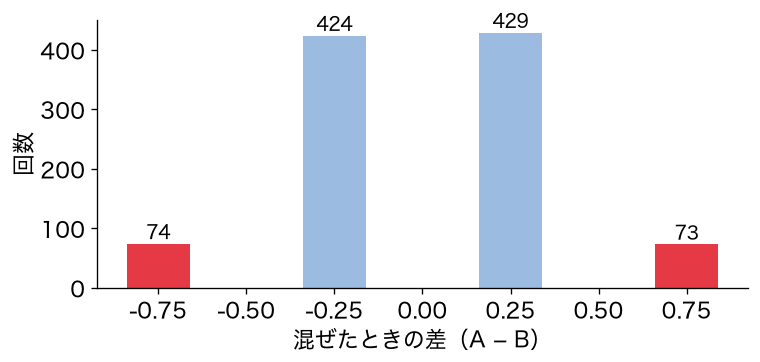

- 赤い棒が、実際と同じか、それより大きい差（±0.75）

## 3対0でも、偶然で出る

2節 ④ 8人●●●●●●

- 1,000回のうち147回（14.7%）で、差の大きさが0.75以上
- 見出しがクリックに関係なくても、7回に1回は、これくらいの差が出る
- 8人では、3対0でも「偶然では出にくい」とは言えない

## p値

2節 ⑤ p値●○

- 帰無仮説のもとで、実際の差と同じか、それより大きい差が出る割合を、p値という
- 並べ替えなら $p = \dfrac{|d^{(r)}| \ge |d_{\text{実際}}| \text{ だった回数}}{\text{くり返した回数}}$
- $d^{(r)}$は、$r$回目に混ぜたときの差

## 重要概念：p値

2節 ⑤ p値●●

p値は、差が無いとしたときに、実際の差と同じかそれ以上の差が、偶然に出る割合。小さければ「偶然では出にくい」と言える。

## 本番：13,452回の表示

2節 ⑥ 本番●○○○○

- 8人を、Aの6,642回とBの6,810回の表示に替える
- 13,452枚の札（1が150枚）を混ぜ、前の6,642枚をA、残りをBにする
- これを1万回くり返す

## お手本：本番で混ぜる

2節 ⑥ 本番●●○○○

```python
x = np.concatenate([a, b])
na = len(a)
obs = a.mean() - b.mean()
rng = np.random.default_rng(0)
diffs = []
for i in range(10000):
    y = rng.permutation(x)
    diffs.append(y[:na].mean() - y[na:].mean())
diffs = np.array(diffs)
print(len(x), x.sum(), round(obs, 4))
```

```
13452 150 0.0056
```

## 1行ずつ：本番で混ぜる①

2節 ⑥ 本番●●●○○

```python
x = np.concatenate([a, b])
na = len(a)
obs = a.mean() - b.mean()
rng = np.random.default_rng(0)
diffs = []
for i in range(10000):
    y = rng.permutation(x)
    diffs.append(y[:na].mean() - y[na:].mean())
diffs = np.array(diffs)
print(len(x), x.sum(), round(obs, 4))
```

- 1行目：AとBの0/1を、1本につなぐ（`concatenate`）。札の山
- 2行目：Aの札の数（6,642）
- 3行目：実際の差（0.0056）

## 1行ずつ：本番で混ぜる②

2節 ⑥ 本番●●●●○

```python
x = np.concatenate([a, b])
na = len(a)
obs = a.mean() - b.mean()
rng = np.random.default_rng(0)
diffs = []
for i in range(10000):
    y = rng.permutation(x)
    diffs.append(y[:na].mean() - y[na:].mean())
diffs = np.array(diffs)
print(len(x), x.sum(), round(obs, 4))
```

- 4〜8行目：8人のときと同じ形。混ぜて、前の`na`枚と残りの差をリストにためる
- 9行目：あとで計算しやすいように、リストを配列にする
- 10行目：札の数13,452、1の数150、実際の差

## 中身を見る：3回だけ

2節 ⑥ 本番●●●●●

```python
rng = np.random.default_rng(0)
diffs2 = []
for i in range(3):
    y = rng.permutation(x)
    diffs2.append(y[:na].mean() - y[na:].mean())
    print(y[:na].sum(), y[na:].sum(), np.array(diffs2).round(4))
```

```
68 82 [-0.0018]
73 77 [-0.0018 -0.0003]
68 82 [-0.0018 -0.0003 -0.0018]
```

- 150のクリックが、混ぜるたびにAとBに分かれ直す。差は0のまわり

## お手本：分布を描く

2節 ⑦ 分布●○○

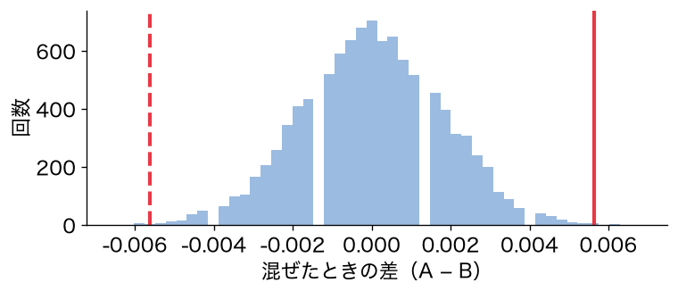

```python
plt.hist(diffs, bins=50)
plt.axvline(obs, color='red')
plt.axvline(-obs, color='red', linestyle='--')
plt.xlabel('混ぜたときの差（A − B）')
plt.ylabel('回数')
plt.show()
```

## 1行ずつ：分布を描く

2節 ⑦ 分布●●○

```python
plt.hist(diffs, bins=50)
plt.axvline(obs, color='red')
plt.axvline(-obs, color='red', linestyle='--')
plt.xlabel('混ぜたときの差（A − B）')
plt.ylabel('回数')
plt.show()
```

- 1行目：1万個の差のヒストグラム
- 2行目：実際の差の位置に、赤い縦線（`axvline`）
- 3行目：反対側（Bが0.56ポイント上回る側）にも、点線

## 実際の差は、ほとんど出ない

2節 ⑦ 分布●●●

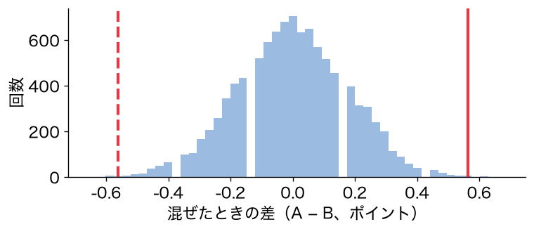

- 混ぜた差の山は、0のまわり。実際の差（0.56ポイント）は、山の外れ

## お手本：p値を数える

2節 ⑧ p値を数える●○

```python
p = (np.abs(diffs) >= obs).mean()
print(p)
```

```
0.0022
```

- 1万回のうち22回だけ。p値は0.0022

## 1行ずつ：p値を数える

2節 ⑧ p値を数える●●

```python
p = (np.abs(diffs) >= obs).mean()
print(p)
```

- `np.abs(diffs) >= obs`：差の大きさが実際の差以上ならTrue（第6回の比較）
- `.mean()`：Trueを1、Falseを0として平均する。Trueだった割合
- 8人のときと同じ数え方

## 有意

2節 ⑨ 有意●○○

- p値が、前もって決めた小さな値（ふつうは0.05）より小さいとき、差は「有意」という
- この0.05を、有意水準という
- 0.0022 < 0.05。見出しAとBの差は有意

## 並べ替え検定

2節 ⑨ 有意●●○

- 札を混ぜて、差が無い世界の差の分布を作り、p値を数える。これを並べ替え検定という
- 式を使わない。混ぜて、測って、くり返して、数える
- 来た人をでたらめに分けた実験なら、そのまま使える

## 重要：p値は差の大きさではない

2節 ⑨ 有意●●●

p値が小さいのは「偶然では出にくい」ということ。差が大きいこととは別。表示の数が多ければ、小さな差でもp値は小さくなる。

## TODO②：くり返しの回数を替える

2節 10 回数●○

```python
# TODO: 10000 を 100 に替えて実行する
rng = np.random.default_rng(0)
dx = []
for i in range(10000):
    y = rng.permutation(x)
    dx.append(y[:na].mean() - y[na:].mean())
dx = np.array(dx)
print((np.abs(dx) >= obs).mean())
```

- 予想：100回しか混ぜないと、p値はどうなるか

## ここまでで分かったこと

2節 10 回数●●

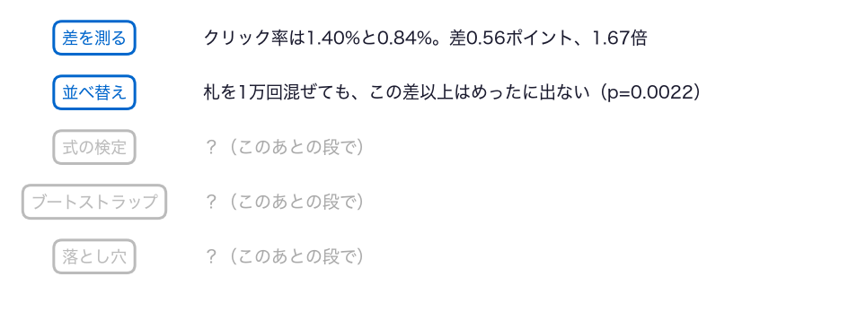

- まだ分からないのは、式で出すp値と、並べ替えのp値が合うかどうか

## ノートへ：2節

2節 11 ノートへ●

- 2節のセルを上から実行し、スライドと同じ数が出るか確かめる
- TODO②：予想を書く → `10000`を`100`に替えて実行 → 予想と比べる

動画の人は、ここで一時停止。

## 答え合わせ：TODO②

2節 12 答え合わせ●

```
0.0
0.002
```

- 100回では、実際の差以上が1回も出ず、p値は0.0
- 「p値が0」ではなく、「100回では足りない」。1,000回なら0.002、1万回なら0.0022

# 3. 式でも同じ答え？

## 段3：式の検定

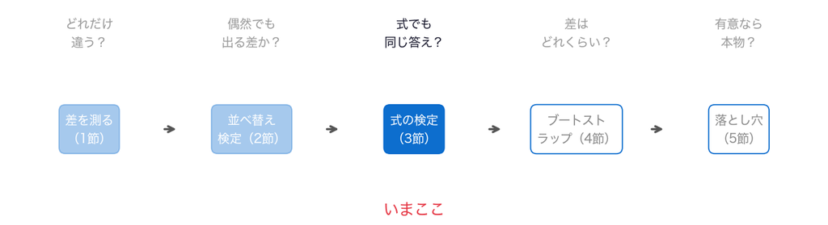

- 問い：式で出すp値は、並べ替えのp値と合うか

## 前の段から

3節 ① 前の段から●

- 札を1万回混ぜると、実際の差以上は22回。p値は0.0022
- 0.05より小さいので、差は有意
- 混ぜずに、式だけでp値を出す方法もある

## 式の検定

3節 ② 式の検定●

- 計算機の無い時代から、差が無い世界の差の分布を、式で求めてきた
- 割合の差ならカイ二乗検定、平均の差ならt検定
- 論文には、こちらがよく出てくる

## 2×2の表

3節 ③ 表●○

|  | クリック | しない |
| --- | --- | --- |
| A | 93 | 6549 |
| B | 57 | 6753 |

- 行が見出し、列がクリックしたかどうか。4つのマスに数を入れる

## お手本：2×2の表

3節 ③ 表●●

```python
table = [[k[0], n[0] - k[0]],
         [k[1], n[1] - k[1]]]
print(table)
```

```
[[93, 6549], [57, 6753]]
```

- 1行目：Aのクリックとしなかった数。2行目：Bの同じ数（リストのリスト）

## 差が無いときの数

3節 ④ 期待度数●

- 差が無いなら、AもBも、全体のクリック率（150 / 13,452）でクリックされるはず
- Aで期待されるクリック：$6{,}642 \times \dfrac{150}{13{,}452} = 74.1$
- 差が無いときに期待される数を、期待度数という。行の和×列の和÷全体

## お手本：カイ二乗検定

3節 ⑤ カイ二乗●○○○

```python
from scipy import stats
res = stats.chi2_contingency(table, correction=False)
print(round(res.pvalue, 4))
print(res.expected_freq.round(1))
```

```
0.0019
[[  74.1 6567.9]
 [  75.9 6734.1]]
```

## 1行ずつ：カイ二乗検定

3節 ⑤ カイ二乗●●○○

```python
from scipy import stats
res = stats.chi2_contingency(table, correction=False)
print(round(res.pvalue, 4))
print(res.expected_freq.round(1))
```

- 1・2行目：検定の道具を呼び、2×2の表を渡す（`correction=False`は、小さな数のための補正を外す指定）
- 3行目：p値は0.0019
- 4行目：差が無いときに期待される数（期待度数）

## カイ二乗検定がしていること

3節 ⑤ カイ二乗●●●○

- 4つのマスで、実際の数$O$と期待度数$E$のずれを測る
- $\chi^2 = \sum \dfrac{(O - E)^2}{E}$。ずれが大きいほど大きい
- 差が無い世界で$\chi^2$がどう散らばるかは、式で分かっている。そこからp値を出す

## 中身を見る：4つのマスのずれ

3節 ⑤ カイ二乗●●●●

```python
O = np.array(table)
E = res.expected_freq
print(((O - E) ** 2 / E).round(2))
print(round(res.statistic, 2))
```

```
[[4.84 0.05]
 [4.72 0.05]]
9.67
```

- ずれのほとんどは、クリックの列（Aは多すぎ、Bは少なすぎ）から来る

## 並べ替えと、ほぼ同じ

3節 ⑥ 比べる●○

- 並べ替え（1万回）：0.0022
- カイ二乗検定：0.0019
- 別のやり方で、ほぼ同じ答え

## なぜ合う？

3節 ⑥ 比べる●●

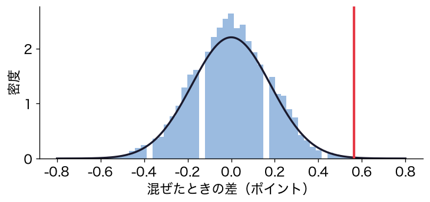

- 表示の数が多いと、混ぜた差の分布は正規分布（黒い線）にほぼ重なる。式はこの線を使う

## お手本：t検定

3節 ⑦ t検定●○

```python
res_t = stats.ttest_ind(a, b)
print(round(res_t.pvalue, 4))
```

```
0.0019
```

- 0/1の列の平均を比べるt検定でも、p値は0.0019

## t検定がしていること

3節 ⑦ t検定●●

- 平均の差を、その揺れの大きさ（標準誤差）で割る：$t = \dfrac{\bar{a} - \bar{b}}{\text{標準誤差}}$
- 差が無い世界で$t$がどう散らばるかは、式で分かっている
- 0/1の平均はクリック率なので、割合の比べ方と同じ答えになる

## 片側と両側

3節 ⑧ 片側●○○

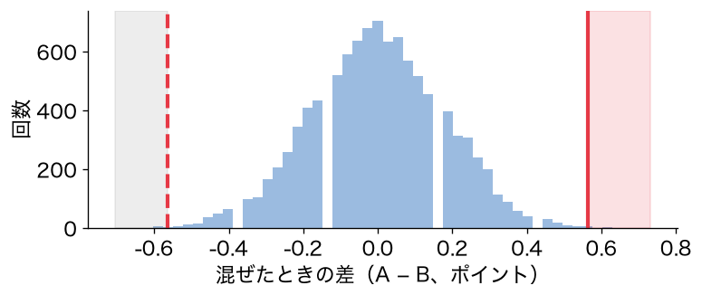

- 両側：AとBのどちらが上でも数える（ここまで）。片側：Aが上の側だけ数える

## どちらを使う？

3節 ⑧ 片側●●○

- 片側のp値は、両側のほぼ半分になる
- 「Aのほうが上か」だけを前もって問うなら、片側
- データを見てから片側に切り替えるのは、ずるい。ふつうは両側

## 重要：式は、並べ替えの近道

3節 ⑧ 片側●●●

カイ二乗検定やt検定は、札を混ぜる代わりに、差が無い世界の分布を式で出す近道。数が多ければ、並べ替えと同じ答えになる。

## TODO③：片側にする

3節 ⑨ 片側にする●○

```python
# TODO: 'two-sided' を 'greater' に替えて実行する
res_x = stats.ttest_ind(a, b, alternative='two-sided')
print(round(res_x.pvalue, 4))
```

- `'greater'`は「Aのほうが大きいか」だけを問う片側
- 予想：片側にすると、p値はどうなるか

## ここまでで分かったこと

3節 ⑨ 片側にする●●

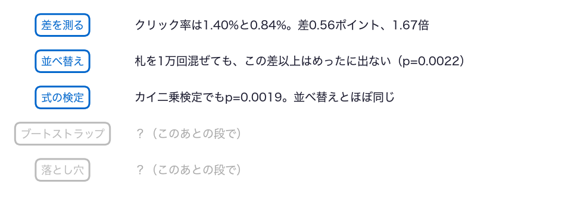

- まだ分からないのは、差が本物だとして、どれくらいの大きさか

## ノートへ：3節

3節 10 ノートへ●

- 3節のセルを上から実行し、スライドと同じ数が出るか確かめる
- TODO③：予想を書く → `'two-sided'`を`'greater'`に替えて実行 → 予想と比べる

動画の人は、ここで一時停止。

## 答え合わせ：TODO③

3節 11 答え合わせ●

```
0.0009
0.0011
```

- 片側のp値は0.0009。両側（0.0019）のほぼ半分
- 並べ替えでも、Aが上の側だけ数えると0.0011

# 4. 差はどれくらい？

## 段4：ブートストラップ

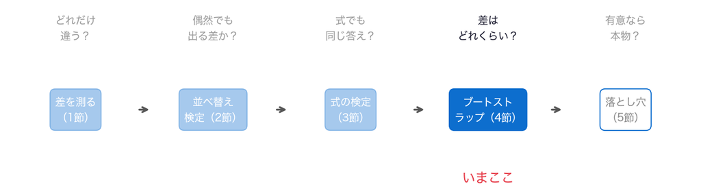

- 問い：差が本物だとして、どれくらいの大きさか

## 前の段から

4節 ① 前の段から●

- 並べ替えでも、式でも、p値は0.002ほど。差は有意
- でも、p値は差の大きさを言わない
- 0.56ポイントは、どれくらい確かな値か

## 問いが変わる

4節 ② 問いが変わる●○

- 検定の問い：差はあるか（差が無い世界で、どれくらい珍しいか）
- 今度の問い：差はどれくらいか（もう一度テストしたら、どれくらいの差が出そうか）
- 答えは、1つの値ではなく、幅（区間）で言う

## もう一度テストできたら

4節 ② 問いが変わる●●

- 同じテストを何度もできれば、差がどれくらい揺れるか分かる
- でも、テストは1回きり
- そこで、手元のデータを「世界の縮図」とみなして、そこから取り直す

## 戻しながら取り直す

4節 ③ 取り直す●○

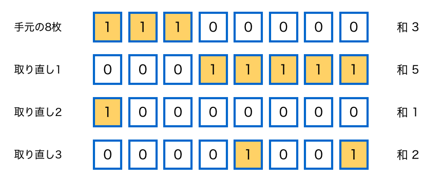

- 8枚から1枚引いて記録し、山に戻す。これを8回。同じ札が2回出ることも、1回も出ないこともある

## 復元抽出とブートストラップ

4節 ③ 取り直す●●

- 引いた札を戻しながら取り直すことを、復元抽出という
- 手元のデータから復元抽出をくり返し、測った値の揺れを見る方法を、ブートストラップという
- 並べ替えは「混ぜる」、ブートストラップは「戻しながら取り直す」

## お手本：8枚から取り直す

4節 ④ 8枚●

```python
rng = np.random.default_rng(0)
for i in range(3):
    print(rng.choice(x8, size=8))
```

```
[0 0 0 1 1 1 1 1]
[1 0 0 0 0 0 0 0]
[0 0 0 0 1 0 0 1]
```

- `choice`は、`x8`から8枚を、戻しながら取る。1の数が毎回変わる

## お手本：本番で取り直す

4節 ⑤ 本番●○○○○

```python
rng = np.random.default_rng(0)
boot = []
for i in range(10000):
    ra = rng.choice(a, size=len(a))
    rb = rng.choice(b, size=len(b))
    boot.append(ra.mean() - rb.mean())
boot = np.array(boot)
print(round(boot.mean(), 4), round(boot.std(), 4))
```

```
0.0056 0.0018
```

## 1行ずつ：本番で取り直す①

4節 ⑤ 本番●●○○○

```python
rng = np.random.default_rng(0)
boot = []
for i in range(10000):
    ra = rng.choice(a, size=len(a))
    rb = rng.choice(b, size=len(b))
    boot.append(ra.mean() - rb.mean())
boot = np.array(boot)
print(round(boot.mean(), 4), round(boot.std(), 4))
```

- 1行目：乱数の道具を、シード0で作る
- 2行目：差をためる空のリスト
- 3行目：1万回くり返す

## 1行ずつ：本番で取り直す②

4節 ⑤ 本番●●●○○

```python
rng = np.random.default_rng(0)
boot = []
for i in range(10000):
    ra = rng.choice(a, size=len(a))
    rb = rng.choice(b, size=len(b))
    boot.append(ra.mean() - rb.mean())
boot = np.array(boot)
print(round(boot.mean(), 4), round(boot.std(), 4))
```

- 4・5行目：Aの6,642枚から6,642枚、Bの6,810枚から6,810枚を、戻しながら取る
- 6行目：取り直したAとBの差を、リストの後ろに足す
- 7・8行目：配列にして、差の平均（0.0056）と標準偏差

## 中身を見る：3回だけ

4節 ⑤ 本番●●●●○

```python
rng = np.random.default_rng(0)
boot2 = []
for i in range(3):
    ra = rng.choice(a, size=len(a))
    rb = rng.choice(b, size=len(b))
    boot2.append(ra.mean() - rb.mean())
    print(ra.sum(), rb.sum(), np.array(boot2).round(4))
```

```
106 59 [0.0073]
89 63 [0.0073 0.0041]
102 54 [0.0073 0.0041 0.0074]
```

- Aのクリックは93のまわり、Bは57のまわりで揺れる。差も揺れる

## 1回ごとに、後ろに1つ足す

4節 ⑤ 本番●●●●●

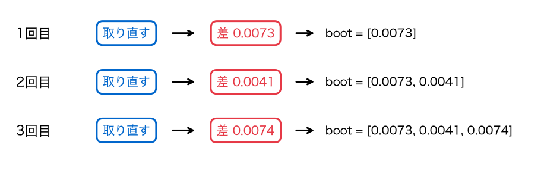

- 1回分の「取り直して、差を測る」をくり返し、リストにためていく

## お手本：分布を描く

4節 ⑥ 区間●○○○

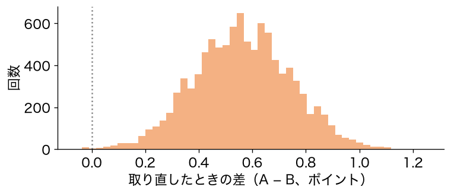

```python
plt.hist(boot, bins=50)
plt.axvline(0, color='gray', linestyle=':')
plt.xlabel('取り直したときの差（A − B）')
plt.ylabel('回数')
plt.show()
```

## 95%区間

4節 ⑥ 区間●●○○

- 取り直した1万個の差を小さい順に並べる
- 下から2.5%の値と、上から2.5%の値の間に、真ん中の95%が入る
- この幅を、95%区間という（パーセンタイル法）

## お手本：区間を出す

4節 ⑥ 区間●●●○

```python
lo, hi = np.percentile(boot, [2.5, 97.5])
print(round(lo, 4), round(hi, 4))
```

```
0.0022 0.0092
```

- 1行目：2.5パーセンタイルと97.5パーセンタイル（`percentile`）を、`lo`と`hi`に入れる
- 差は0.0022〜0.0092。0.22〜0.92ポイント

## 区間を描く

4節 ⑥ 区間●●●●

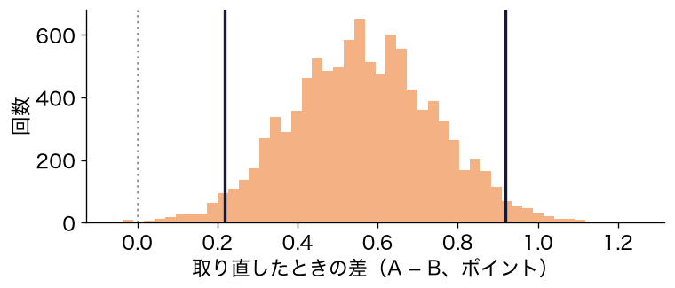

- 黒い線の間が95%区間。点線の0は、区間の外

## 区間の読み方

4節 ⑦ 読み方●○

- 見出しAは、Bより0.2〜0.9ポイントほど、クリック率が高そう
- 小さければ0.2ポイント、大きければ0.9ポイント。幅は広い
- 1回のテストで言えるのは、ここまで

## 区間と検定

4節 ⑦ 読み方●●

- 95%区間が0を含まない ⇔ 両側の検定でp < 0.05、とおおよそ対応する
- 区間は「差があるか」と「どれくらいか」の両方に答える
- 論文では、p値と区間を組で書くことが多い

## 並べ替えとブートストラップは鏡

4節 ⑧ 鏡●

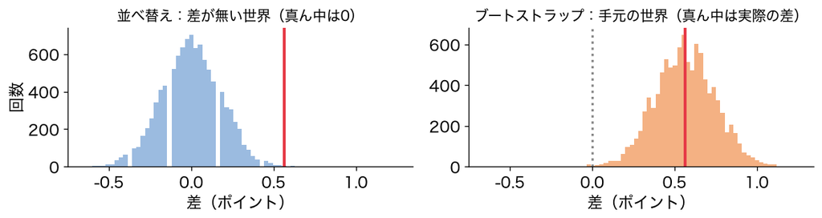

- 左は差が無い世界で、実際の差を見る。右は手元の世界で、0を見る

## 式が無い量でも

4節 ⑨ 比●○

- 差の区間は、式でも出せる（標準誤差 × 1.96）
- 比（何倍か）の区間は、教科書の式が少しややこしい
- ブートストラップなら、測るものを替えるだけ。同じ手順で出る

## お手本：比の区間

4節 ⑨ 比●●

```python
rng = np.random.default_rng(0)
ratios = []
for i in range(10000):
    ra = rng.choice(a, size=len(a))
    rb = rng.choice(b, size=len(b))
    ratios.append(ra.mean() / rb.mean())
print(np.percentile(ratios, [2.5, 97.5]).round(2))
```

```
[1.22 2.36]
```

- 6行目だけが違う（差`-`を比`/`に）。Aは、Bの1.22〜2.36倍

## 4案のテスト

4節 10 4案●○○

- ディズニー映画の記事。見出しだけ違う4案
- ①「ディズニーが見せたくない、プリンセス映画の“正しすぎる”別の結末」②「笑：①と同じ」
- ③「『めでたしめでたし』のあとに起きる、不穏な本当の話」④「ディズニー映画は嘘で終わる。その続き」

## 4案のクリック率

4節 10 4案●●○

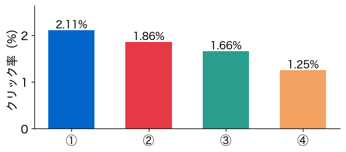

- ①が1位。でも、もう一度テストしたら、①は1位のままか

## お手本：4案を0/1の列に

4節 10 4案●●●

```python
d4 = df[df['テスト'] == '5143608a220cb800020009c0']
n4 = d4['表示'].tolist()
k4 = d4['クリック'].tolist()
arms = []
for j in range(4):
    arms.append(np.repeat([1, 0], [k4[j], n4[j] - k4[j]]))
print(n4, k4)
```

```
[3276, 3232, 3138, 3441] [69, 60, 52, 43]
```

- 4案の0/1の列を、リスト`arms`にためる

## お手本：1位が残る割合

4節 11 1位●○○○○

```python
rng = np.random.default_rng(0)
wins = []
for i in range(10000):
    r = []
    for z in arms:
        r.append(rng.choice(z, size=len(z)).mean())
    wins.append(np.argmax(r))
print(pd.Series(wins).value_counts(normalize=True).sort_index())
```

```
0    0.7393
1    0.2024
2    0.0579
3    0.0004
Name: proportion, dtype: float64
```

## 1行ずつ：1位が残る割合

4節 11 1位●●○○○

```python
rng = np.random.default_rng(0)
wins = []
for i in range(10000):
    r = []
    for z in arms:
        r.append(rng.choice(z, size=len(z)).mean())
    wins.append(np.argmax(r))
print(pd.Series(wins).value_counts(normalize=True).sort_index())
```

- 3〜6行目：1万回くり返す。毎回、4案それぞれを取り直し、クリック率をリスト`r`にためる（入れ子の`for`、第9回）
- 7行目：いちばん大きい率の番号（0が①）を、`wins`に足す（`argmax`）
- 8行目：番号ごとの割合

## ①が1位に残るのは74%

4節 11 1位●●●○○

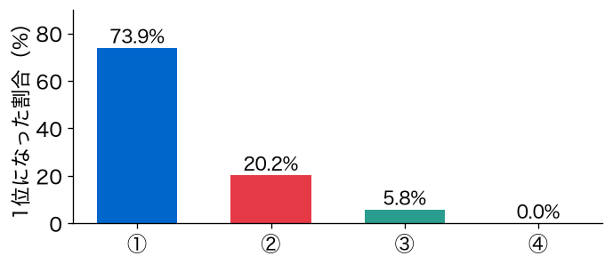

- 4回に1回は、②か③が1位になる。「1位の案」にも、揺れがある

## 1位が残る割合には、式が無い

4節 11 1位●●●●○

- 「何%の確率で1位のままか」を出す、簡単な式は無い
- ブートストラップなら、測るもの（いちばん大きい番号）を替えるだけ
- 取り直して、測って、くり返す。手順は同じ

## 重要概念：取り直してくり返す

4節 11 1位●●●●●

1回分の「取り直して測る」を`for`で何千回もくり返し、結果をリストにためると、偶然のばらつきの分布ができる。混ぜれば並べ替え検定、戻しながら取れればブートストラップ。

## ブートストラップの限界

4節 12 限界●

- 手元のデータが、世界の縮図になっているときだけ使える
- 数が少ないと、縮図になっていない（8人なら、8枚の中からしか取れない）
- 来た人をでたらめに分けていない比べ方の偏りは、取り直しても直らない

## TODO④：区間の幅を替える

4節 13 幅●○

```python
# TODO: [2.5, 97.5] を [0.5, 99.5] に替えて実行する
print(np.percentile(boot, [2.5, 97.5]).round(4))
```

- `[0.5, 99.5]`は、真ん中の99%が入る区間（99%区間）
- 予想：99%区間は、0を含むか

## ここまでで分かったこと

4節 13 幅●●

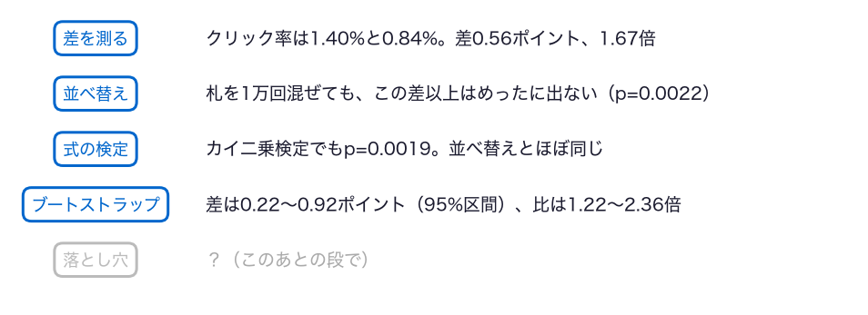

- まだ分からないのは、「有意」なら本物と言ってよいか

## ノートへ：4節

4節 14 ノートへ●

- 4節のセルを上から実行し、スライドと同じ数が出るか確かめる
- TODO④：予想を書く → `[2.5, 97.5]`を`[0.5, 99.5]`に替えて実行 → 予想と比べる

動画の人は、ここで一時停止。

## 答え合わせ：TODO④

4節 15 答え合わせ●

```
[0.0009 0.0103]
```

- 99%区間は0.0009〜0.0103。95%より広いが、まだ0を含まない
- p値0.0022は0.01より小さい。99%区間が0を含まないのと対応する

# 5. 有意なら本物？

## 段5：落とし穴

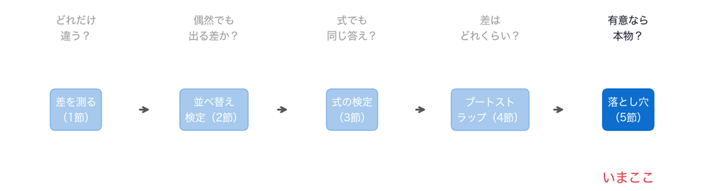

- 問い：「有意」なら、本物の差と言ってよいか

## 前の段から

5節 ① 前の段から●

- 見出しAとBの差は有意（p=0.0022）。区間は0.22〜0.92ポイント
- 4案のテストでは、1位が1位に残るのは74%
- 有意という言葉は、どれくらい信じてよいか

## 同じ案を並べたテスト

5節 ② 同じ案●○

- Upworthyは、まったく同じ案を2つ以上並べたテストもしていた
- 見出し・画像・説明・本文の書き出しが、すべて同じ
- 差が無いと分かっている比べ方。A/Aテストという

## お手本：投票の記事

5節 ② 同じ案●●

```python
v = df[df['テスト'] == '54592bf482ab36427f000055']
v[['見出し', '表示', 'クリック']]
```

|  | 見出し | 表示 | クリック |
| --- | --- | --- | --- |
| 19630 | A Guy Does Some Simple Math To Explain Why S… | 3716 | 24 |
| 19631 | A Guy Does Some Simple Math To Explain Why S… | 3742 | 26 |
| 19632 | A Guy Does Some Simple Math To Explain Why S… | 3661 | 48 |
| 19633 | A Guy Does Some Simple Math To Explain Why S… | 3746 | 30 |

- 4案とも同じ見出し「ある男が簡単な計算で、『自分の1票は意味がない』が間違いだと説明する」

## 何度も書いたので、関数にする

5節 ③ 関数●○○

- 0/1の列を作る`np.repeat`と、p値を出す`chi2_contingency`を、何度も書いた
- この先も何度も使うので、1回分を返す関数にまとめる（第3回の`def`）
- 中身は、ここまでのセルと同じ

## お手本：2つの関数

5節 ③ 関数●●○

```python
def to01(k, n):
    return np.repeat([1, 0], [k, n - k])


def pval(u, w):
    table = [[u.sum(), len(u) - u.sum()],
             [w.sum(), len(w) - w.sum()]]
    return stats.chi2_contingency(table, correction=False).pvalue
```

## 1行ずつ：2つの関数

5節 ③ 関数●●●

```python
def to01(k, n):
    return np.repeat([1, 0], [k, n - k])


def pval(u, w):
    table = [[u.sum(), len(u) - u.sum()],
             [w.sum(), len(w) - w.sum()]]
    return stats.chi2_contingency(table, correction=False).pvalue
```

- 1・2行目：クリックの数`k`と表示の数`n`から、0/1の列を返す
- 5〜8行目：2つの0/1の列から2×2の表を作り、カイ二乗検定のp値を返す
- 関数の中の`k`・`n`は、外のリスト`k`・`n`とは別物（第3回）。外のリストは壊れない

## お手本：同じ案どうしを比べる

5節 ④ 比べる●○

```python
nv = v['表示'].tolist()
kv = v['クリック'].tolist()
u = to01(kv[0], nv[0])
w = to01(kv[2], nv[2])
print(round(u.mean(), 4), round(w.mean(), 4))
print(round(pval(u, w), 4))
```

```
0.0065 0.0131
0.0037
```

- 案1と案3（シェア用の文まで、まったく同じ2案）を比べる

## えっ、同じ見出しで2倍

5節 ④ 比べる●●

- 同じ案なのに、クリック率は0.65%と1.31%。2倍
- p値は0.0037。0.05より小さく、「有意」
- 差が無いと分かっているのに、有意になった

## 道具：同じ案の組を探す

5節 ⑤ 51組●○

```python
aa = same_pairs(df)
print(len(aa), (aa['p'] < 0.05).sum())
```

```
51 2
```

- `same_pairs`は、ノートの折りたたみに置いた道具の関数（中身は読み飛ばしてよい）
- 同じテストの中で、まったく同じ案の組を探し、組ごとに`pval`でp値を出す

## 51組のうち2組

5節 ⑤ 51組●●

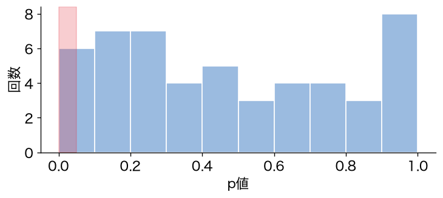

- 同じ案の51組のうち、2組（3.9%）がp < 0.05。投票の記事はその1つ

## A/Aテストを作る

5節 ⑥ 作る●○○

- 51組では、少なすぎて割合がはっきりしない
- 見出しAの6,642回の表示を、でたらめに半分に分ければ、A/Aテストが作れる
- これを1,000回くり返し、p < 0.05になる割合を数える

## お手本：A/Aを1,000回

5節 ⑥ 作る●●○

```python
rng = np.random.default_rng(0)
ps = []
for i in range(1000):
    y = rng.permutation(a)
    ps.append(pval(y[:3321], y[3321:]))
ps = np.array(ps)
print((ps < 0.05).mean())
```

```
0.061
```

## 1行ずつ：A/Aを1,000回

5節 ⑥ 作る●●●

```python
rng = np.random.default_rng(0)
ps = []
for i in range(1000):
    y = rng.permutation(a)
    ps.append(pval(y[:3321], y[3321:]))
ps = np.array(ps)
print((ps < 0.05).mean())
```

- 3・4行目：1,000回、Aの6,642枚を混ぜる
- 5行目：前の3,321枚と後ろの3,321枚のp値を、リストにためる
- 6・7行目：p < 0.05だった割合

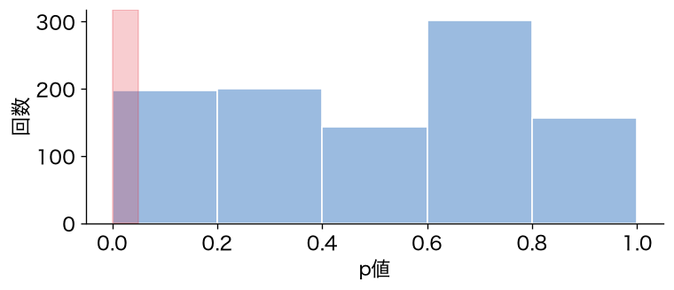

## 5%は、差が無くても5%

5節 ⑦ 平ら●●

- 有意水準0.05で判定すると、差が無くても、20回に1回は「有意」になる
- 1,000回のうち61回（6.1%）。投票の記事も、その20回に1回だった
- 「有意」は「偶然では出にくい」であって、「本物の証明」ではない

## たくさん比べると

5節 ⑧ 多重比較●○○○

- 4案のテストなら、2案の組は6組ある
- 6組を全部比べると、どれか1組が「有意」になりやすい
- たくさんの比べ方から有意なものを探すと、偶然の当たりを拾う。多重比較の問題という